# dispRity simulate data

Thomas Guillerme

2017-08-11

# Simulating morphological data in `dispRity`

The `dispRity` package allows users to simulate discrete morphological data matrices. In brief, the function `sim.morpho` takes a phylogenetic tree, the number of required characters, the evolutionary model, and a function from which to draw the rates. The package also contains a function for quickly checking the matrix’s phylogenetic signal (as defined in systematics not phylogenetic comparative methods) using parsimony.

# Before starting

## Installing `dispRity`

You can install this package easily if you are using the latest version of `R` and `devtools`.

```r
if(!require(devtools)) install.packages("devtools")
install_github("TGuillerme/dispRity", ref = "release")
library(dispRity)
```

# A simple example

```r
library(dispRity)
set.seed(123)
## Setting the starting tree with 15 taxa as a random coalescent tree
my_tree <- rcoal(15)

## Generating a matrix with 100 characters (85% binary and 15% three state) and
## an equal rates model with a gamma rate distribution (0.5, 1) with no
## invariant characters.
my_matrix <- sim.morpho(tree = my_tree, characters = 100, states = c(0.85,
    0.15), rates = c(rgamma, 0.5, 1), invariant = FALSE)

## The head of the matrix
my_matrix[1:5, 1:10]
```

```
##     [,1] [,2] [,3] [,4] [,5] [,6] [,7] [,8] [,9] [,10]
## t4  "0"  "0"  "1"  "1"  "2"  "1"  "0"  "0"  "0"  "0"
## t2  "0"  "0"  "1"  "1"  "2"  "1"  "0"  "0"  "0"  "0"
## t10 "0"  "0"  "1"  "0"  "2"  "1"  "1"  "0"  "0"  "0"
## t11 "0"  "0"  "1"  "0"  "0"  "0"  "0"  "0"  "0"  "0"
## t5  "0"  "1"  "0"  "0"  "2"  "0"  "0"  "0"  "1"  "0"
```

```r
## Checking the matrix properties with a quick Maximum Parsimony tree search
check.morpho(my_matrix, my_tree)
```

```
##
## Maximum parsimony        152.0000000
## Consistency index          0.6842105
## Retention index            0.8241758
## Robinson-Foulds distance   6.0000000
```

# A more detailed description

`sim.morpho` is really flexible and takes many different arguments to allow users to simulate realistic matrices. It has three implemented models: `"ER"` for Equal Rates (the M*k* model); `"HKY"`, the molecular HKY model but transforms pyrines in 0’s and pyrimidines in 1’s; or the `"mixed"` model that randomly uses an `"ER"` and/or `"HKY"` for the binary characters and `"ER"` for the multistate (>2) characters. Both models take specific distributions for their rate or substitution models. These distributions should be passed to these arguments in the format of `c(sampler_function, distribution_parameters)` where the the sampler function is a the random generation function of that distribution (e.g. `rnorm`, `runif`, etc…) and the parameters are any parameters to be passed to this function.

`check.morpho` runs a quick Maximum Parsimony tree search using the `phangorn` parsimony algorithm. It quickly calculates the parsimony score, the consistency and retention indices and, if a tree is provided (e.g. the tree used to generate the matrix) it calculates the Robinson-Foulds distance between the most parsimonious tree and the provided tree to determine how different they are.

# Parameters for a realistic(ish) matrix

```r
set.seed(1)
## tree
my_tree <- rcoal(15)
## matrix
morpho_mat <- sim.morpho(my_tree, characters = 100, model = "ER",
    rates = c(rgamma, rate = 100, shape = 5), invariant = FALSE)
check.morpho(morpho_mat, my_tree)
```

[output not shown]

# `space.maker`

Another way to simulate data is to directly simulate an ordinated space with the `space.maker` function. This function allows users to simulate multidimensional spaces with a certain number of properties. It takes as arguments the number of elements (data points) and dimensions to create the space but also permits more fine tuning in the data simulation: it is possible to give a specific distribution to each dimension, provide a correlation matrix to link the dimensions or even provide an *a priori* distribution of the variance for each distributions!

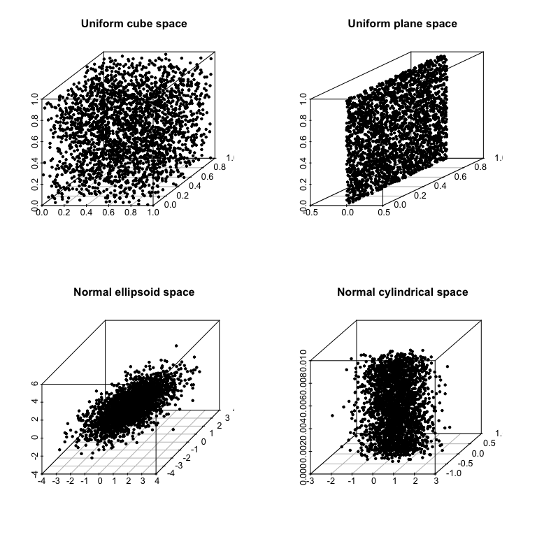

```r
## Graphical options
op <- par(mfrow = (c(2, 2)), bty = "n")
## Visualising 3D spaces
require(scatterplot3d)
## A cube space
scatterplot3d(space.maker(2500, 3, runif), pch = 20,
              xlab = "", ylab = "", zlab = "",
              main = "Uniform cube space")

## A plane space
scatterplot3d(space.maker(2500, 3, c(runif, runif, runif),
              arguments = list(list(min = 0, max = 0), NULL, NULL)), pch = 20,
              xlab = "", ylab = "", zlab = "",
              main = "Uniform plane space")

## An ellipsoid space (=a spheric space with correlation)
cor_matrix <- matrix(cbind(1, 0.8, 0.2, 0.8, 1, 0.7, 0.2, 0.7, 1), nrow = 3)
scatterplot3d(space.maker(2500, 3, rnorm, cor.matrix = cor_matrix), pch = 20,
              xlab = "", ylab = "", zlab = "",
              main = "Normal ellipsoid space")

## A cylindrical space with a decreasing variance per axis
scatterplot3d(space.maker(2500, 3, c(rnorm, rnorm, runif),
              scree = c(0.7, 0.2, 0.1)), pch = 20,
              xlab = "", ylab = "", zlab = "",
              main = "Normal cylindrical space")
```

```r
## Resetting the graphic parameters
par(op)
```